# main

## Project: Concept Bottleneck Models on CelebA (Smiling)

In this project, you will study Concept Bottleneck Models (CBMs) and their variants on a real vision dataset. Using CelebA and Smiling as the prediction target, you will compare:

a standard image classifier (x → y) a concept bottleneck model (x → c → y) a hybrid CBM with a direct side channel (x → y) under varying side-channel dropout You will analyze the tradeoff between accuracy, interpretability, and steerability.

Dataset Use the CelebA dataset provided by torchvision.datasets.CelebA.

Inputs (x): RGB face images Label (y): Smiling Concepts (c): the following fixed subset of CelebA attributes (binary): C_sub (10 concepts):

Mouth_Slightly_Open High_Cheekbones Chubby Narrow_Eyes Bags_Under_Eyes Big_Lips Big_Nose Pointy_Nose Bushy_Eyebrows Arched_Eyebrows Important: Do not include Smiling as a concept.

```python
%pip install pytorch-lightning;
%pip install torchmetrics;
%pip install torchvision;
%pip install torch;
%pip install matplotlib;
%pip install numpy;
%pip install pandas;
%pip install seaborn;
```

```python
from pathlib import Path
from google.colab import drive
drive.mount("/content/drive")
```

```python
CELEBA_ROOT = Path("/content/drive/MyDrive")
```

- Use the official CelebA train/val/test split provided by torchvision Resize images to a fixed resolution (e.g., 128×128)
- Normalize images using ImageNet statistics

Normalizing images before passing them into a pretrained model like ResNet is a preprocessing step that ensures your input data matches the distribution the model was originally trained on. The process has two steps. First, scale raw pixel values from their original range of 0-255 down to 0-1 by dividing by 255. Second, normalize each channel using the ImageNet mean [0.485, 0.456, 0.406] and standard deviation [0.229, 0.224, 0.225], where each value corresponds to the R, G, and B channels respectively. The formula applied per channel is (x - mean) / std. The reason you use ImageNet statistics specifically is that ResNet's weights were learned assuming inputs with that distribution. If you feed in data that looks statistically different, the activations throughout the network will be off, and the pretrained weights become less useful. In PyTorch this is handled cleanly with transforms.Normalize

```python
from torchvision.datasets import CelebA
from torchvision import transforms

transform = transforms.Compose([
    transforms.CenterCrop(178),
    transforms.Resize((224, 224)), # Resnet with ImageNet trained on 224x224
    transforms.ToTensor(),
    transforms.Normalize(mean=[0.485, 0.456, 0.406], std=[0.229, 0.224, 0.225])
])

dataset = CelebA(
    root=str(CELEBA_ROOT),
    split="train",
    target_type="attr",
    transform=transform,
    download=False  # <--- we already have the files in Drive
)

val_dataset = CelebA(root=str(CELEBA_ROOT), split="valid", target_type="attr", transform=transform, download=False)
test_dataset = CelebA(root=str(CELEBA_ROOT), split="test",  target_type="attr", transform=transform, download=False)



print("Train size:", len(dataset))
print("Valid size:", len(val_dataset))
print("Test size:", len(test_dataset))
```

```
Train size: 162770
Valid size: 19867
Test size: 19962
```

```python
import os
from torch.utils.data import Subset

def get_valid_celeba_indices(dataset):
    """Indices where the image file exists."""
    base = os.path.join(dataset.root, dataset.base_folder, "img_align_celeba")
    valid = []
    for i in range(len(dataset)):
        path = os.path.join(base, dataset.filename[i])
        if os.path.isfile(path):
            valid.append(i)
    return valid

# After creating dataset, val_dataset, test_dataset:
train_valid = get_valid_celeba_indices(dataset)
dataset = Subset(dataset, train_valid)

val_valid = get_valid_celeba_indices(val_dataset)
val_dataset = Subset(val_dataset, val_valid)

test_valid = get_valid_celeba_indices(test_dataset)
test_dataset = Subset(test_dataset, test_valid)
```

[output not shown]

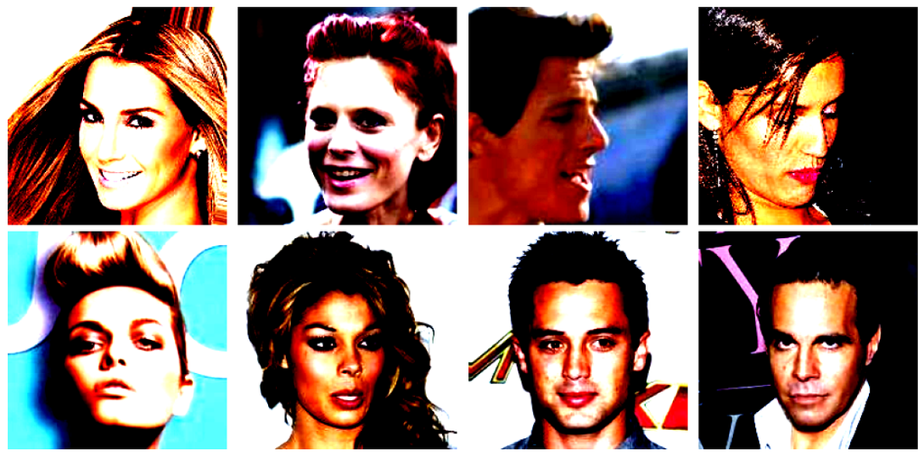

```python
import matplotlib.pyplot as plt

def show_batch(dataset, num=8, figsize=(12, 6)):
    fig, axs = plt.subplots(2, 4, figsize=figsize)
    axs = axs.flatten()
    for i in range(min(num, len(dataset))):
        img, _ = dataset[i]
        # If tensor is (C, H, W), convert to (H, W, C) for imshow
        if img.dim() == 3:
            img = img.permute(1, 2, 0)
        axs[i].imshow(img.clamp(0, 1))
        axs[i].axis("off")
    plt.tight_layout()
    plt.show()

show_batch(dataset, num=8)
```

```python
print(dataset.attr_names)
```

[output not shown]

Report class balance for Smiling and each concept

```
Smiling                    47.97% positive
Mouth_Slightly_Open        48.22% positive
High_Cheekbones            45.24% positive
Chubby                     5.77% positive
Narrow_Eyes                11.59% positive
Bags_Under_Eyes            20.45% positive
Big_Lips                   24.09% positive
Big_Nose                   23.56% positive
Pointy_Nose                27.55% positive
Bushy_Eyebrows             14.37% positive
Arched_Eyebrows            26.59% positive
```

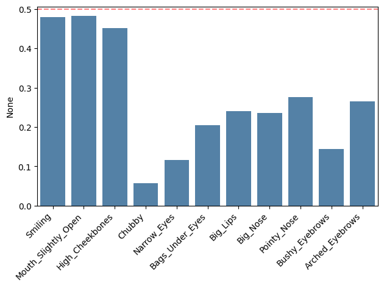

```python
import seaborn as sns

LABEL_NAME = 'Smiling'
CONCEPT_NAMES = ["Mouth_Slightly_Open", "High_Cheekbones",
                 "Chubby", "Narrow_Eyes", "Bags_Under_Eyes",
                 "Big_Lips", "Big_Nose", "Pointy_Nose",
                 "Bushy_Eyebrows", "Arched_Eyebrows"]

names = [LABEL_NAME] + CONCEPT_NAMES
attr_names = list(dataset.attr_names)
idxs = [attr_names.index(n) for n in names]

props = dataset.attr[:, idxs].float().mean(dim=0)

for n, p in zip(names, props):
    print(f"{n:25s}  {p:.2%} positive")
    sns.barplot(x=names, y=props, color="steelblue")
plt.axhline(0.5, color="red", linestyle="--", alpha=0.5)
plt.xticks(rotation=45, ha="right")
plt.tight_layout()
plt.show()
```

Model architecture Use ResNet-18, available directly from torchvision.models.

Initialize with ImageNet pretrained weights Remove the final classification layer Use the shared backbone for all model variants ResNet-18 is chosen because it is:

- lightweight (~11M parameters)
- well-understood and stable
- fast enough for repeated experiments (dropout sweeps)

#### Why reuse it rather than train from scratch?

ResNet-18 already knows how to detect edges, corners, textures, object parts. These low-level and mid-level features transfer well across vision tasks. Training that from scratch on your own dataset would require a lot more data and compute. You're essentially borrowing 1.2M images worth of learning for free.

#### Why remove the last layer?

The final fc layer is specific to ImageNet's 1000 classes. It's useless for your task. You want the 512-feature representation that precedes it, and then you'll attach your own task-specific head on top — whether that's a different number of output classes, a regression output, or in your case, variants with different dropout configurations.

```python
import torch
from torchvision.models import resnet18, ResNet18_Weights
from torch import nn


resnet = resnet18(weights=ResNet18_Weights.IMAGENET1K_V1)

backbone = nn.Sequential(*list(resnet.children())[:-1])


x = torch.randn(8, 3, 224, 224)
with torch.no_grad():
    out = backbone(x)

print(out.shape)
```

```
torch.Size([8, 512, 1, 1])
```

### 1) Baseline classifier (x → y)

**A standard image classifier: (x → y)**

- ResNet-18 backbone
- Single linear classification head

Report:

- Test Accuracy
- Test AUROC

```python
import torch.nn as nn
import numpy as np
from sklearn.metrics import roc_auc_score
import torch.nn.functional as F

SMILING_IDX = dataset.attr_names.index('Smiling')  # should be 31

class BaselineClassifier(nn.Module):
    def __init__(self):
        super().__init__()
        resnet = resnet18(weights=ResNet18_Weights.IMAGENET1K_V1)
        self.backbone = nn.Sequential(*list(resnet.children())[:-1])  # strip fc
        self.classifier = nn.Linear(512, 1)  # single binary output

    def forward(self, x):
        features = self.backbone(x)
        features = features.flatten(start_dim=1)  # (B, 512)
        return self.classifier(features)           # (B, 1)


def evaluate(model, dataloader, device):
    model.eval()
    all_labels = []
    all_probs = []

    with torch.no_grad():
        for images, labels in dataloader:
            images = images.to(device)
            smiling_labels = labels[:, SMILING_IDX].float()  # extract Smiling only

            logits = model(images).squeeze(1)  # (B,)
            probs = torch.sigmoid(logits)

            all_labels.append(smiling_labels.numpy())
            all_probs.append(probs.cpu().numpy())

    all_labels = np.concatenate(all_labels)
    all_probs = np.concatenate(all_probs)

    preds = (all_probs >= 0.5).astype(int)
    accuracy = (preds == all_labels).mean()
    auroc = roc_auc_score(all_labels, all_probs)

    print(f"Test Accuracy: {accuracy:.4f}")
    print(f"Test AUROC:    {auroc:.4f}")
```

```python
from torch.utils.data import DataLoader

device = torch.device("cuda" if torch.cuda.is_available() else "cpu")

model = BaselineClassifier().to(device)

evaluate(model, DataLoader(test_dataset, batch_size=64, shuffle=False), device)
```

[output not shown]